# Reproducible Research: Peer Assessment 1

## Loading and preprocessing the data

```r
activity <- read.csv("activity.csv")

activity$date <- as.Date(activity$date) # formatting date as date



acti_clear<- complete.cases(activity)

cleared_activity<- activity[acti_clear,] #clearing NA rows
```

## What is mean total number of steps taken per day?

Make a histogram of the total number of steps taken each day

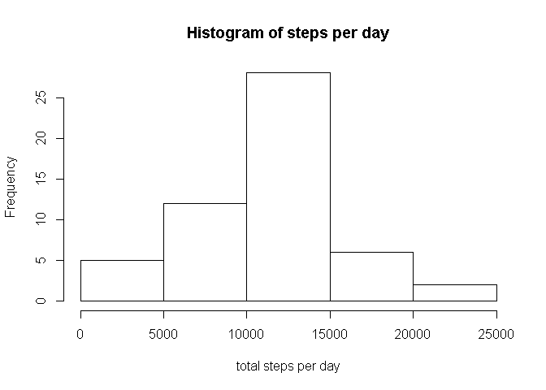

```r
dailystep <- aggregate(cleared_activity[,1],list(date= cleared_activity$date),sum)

hist(dailystep$x, xlab="total steps per day", main= "Histogram of steps per day")
```

```r
#calculating mean first
agg_tbl <-  aggregate(cleared_activity[,1],list(date= cleared_activity$date),mean)

#median next
agg_tbl_med <- aggregate(cleared_activity[,1],list(date= cleared_activity$date),median)

#combining them
agg_tbl<- cbind(agg_tbl,agg_tbl_med[,2])

#rename colums
colnames(agg_tbl)[c(2,3)] <- c("mean", "median")

agg_tbl
```

```
##          date    mean median
## 1  2012-10-02  0.4375      0
## 2  2012-10-03 39.4167      0
## 3  2012-10-04 42.0694      0
## 4  2012-10-05 46.1597      0
## 5  2012-10-06 53.5417      0
## 6  2012-10-07 38.2465      0
## 7  2012-10-09 44.4826      0
## 8  2012-10-10 34.3750      0
## 9  2012-10-11 35.7778      0
## 10 2012-10-12 60.3542      0
## 11 2012-10-13 43.1458      0
## 12 2012-10-14 52.4236      0
## 13 2012-10-15 35.2049      0
## 14 2012-10-16 52.3750      0
```

[output cut: 39 more lines]

## What is the average daily activity pattern?

Make a time series plot of the 5-minute interval and the average number of steps taken, averaged across all days

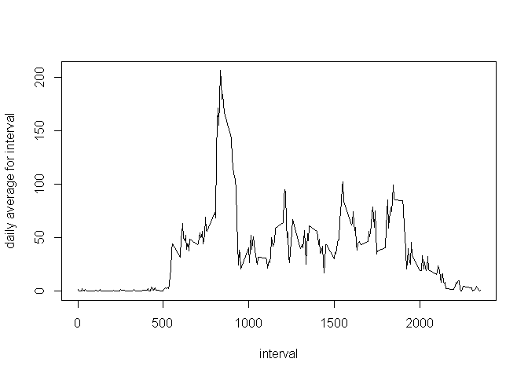

```r
agg_int <-  aggregate(cleared_activity[,1],list(interval= cleared_activity$interval),mean)

with(agg_int,plot(interval,x,type="l", ylab="daily average for interval"))
```

Which 5-minute interval, on average across all the days in the dataset, contains the maximum number of steps?

```r
max_step<- agg_int[agg_int$x== max(agg_int[,2]),1]

max_step
```

```
## [1] 835
```

## Imputing missing values

Calculate and report the total number of missing values in the dataset

```r
nrow(activity[!acti_clear,])
```

```
## [1] 2304
```

Devise a strategy for filling in all of the missing values in the dataset: Missing values will be calculated based on average interval value

```r
ext_activ<- merge(activity, agg_int)
ext_activ[!complete.cases(ext_activ),2]<- ext_activ[!complete.cases(ext_activ),4]
new_activity <- ext_activ[,1:3]
```

Make a histogram of the total number of steps taken each day with the missing values being replaced

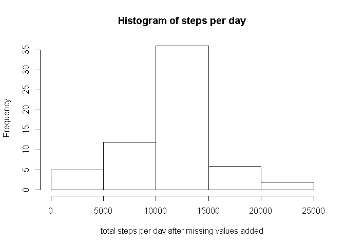

```r
new_dailystep <- aggregate(new_activity[,2],list(date= new_activity$date),sum)

hist(new_dailystep$x, xlab="total steps per day after missing values added",
     main= "Histogram of steps per day")
```

```r
#calculating mean first
new_agg_tbl <-  aggregate(new_activity[,2],list(date= new_activity$date),mean)

#median next
new_agg_tbl_med <- aggregate(new_activity[,2],list(date= new_activity$date),median)

#combining them
new_agg_tbl<- cbind(new_agg_tbl,new_agg_tbl_med[,2])

#rename colums
colnames(new_agg_tbl)[c(2,3)] <- c("mean", "median")

new_agg_tbl
```

```
##          date    mean median
## 1  2012-10-01 37.3826  34.11
## 2  2012-10-02  0.4375   0.00
## 3  2012-10-03 39.4167   0.00
## 4  2012-10-04 42.0694   0.00
## 5  2012-10-05 46.1597   0.00
## 6  2012-10-06 53.5417   0.00
## 7  2012-10-07 38.2465   0.00
## 8  2012-10-08 37.3826  34.11
## 9  2012-10-09 44.4826   0.00
## 10 2012-10-10 34.3750   0.00
## 11 2012-10-11 35.7778   0.00
## 12 2012-10-12 60.3542   0.00
## 13 2012-10-13 43.1458   0.00
## 14 2012-10-14 52.4236   0.00
```

[output cut: 47 more lines]

## Are there differences in activity patterns between weekdays and weekends?

Create a new factor variable in the dataset with two levels - “weekday” and “weekend” indicating whether a given date is a weekday or weekend day.

```r
set_day <- function(x) {

    if (weekdays(as.Date(x)) == "Sunday" | weekdays(as.Date(x)) == "Saturday")
       day <- "weekend"
    else
        day <- "weekday"

    day
}

new_activity$wkday <- as.factor(sapply(new_agg_tbl[,1],set_day))
```

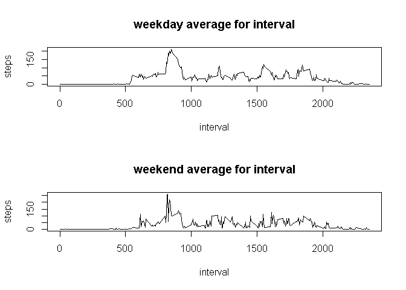

```r
par(mfrow = c(2, 1))

new_agg_int_wkday <-  aggregate(steps~interval,new_activity,mean, subset= new_activity$wkday=="weekday")

with(new_agg_int_wkday,plot(interval,steps,type="l", main="weekday average for interval"))

new_agg_int_wkend <-  aggregate(steps~interval,new_activity,mean, subset= new_activity$wkday=="weekend")

with(new_agg_int_wkend,plot(interval,steps,type="l", main="weekend average for interval"))
```